# Tugas Pertemuan 5

Zanira Husna G1401231097

2025-10-02

```r
library(ggplot2)
library(tsibble)
library(tseries)
library(MASS)
```

## Stasioner dalam Rataan dan Ragam

```r
data <- read.csv("C:\\Users\\ZANIRA\\Downloads\\Data_2.csv")
df <- head(data, 100)
```

```r
str(df)
```

```
## 'data.frame':    100 obs. of  2 variables:
##  $ Period: int  1 2 3 4 5 6 7 8 9 10 ...
##  $ Sales : num  10618 10538 10209 10553 9935 ...
```

```r
ts_data <- ts(df$Sales)  # default freq = 1
```

### Plot *Time Series*

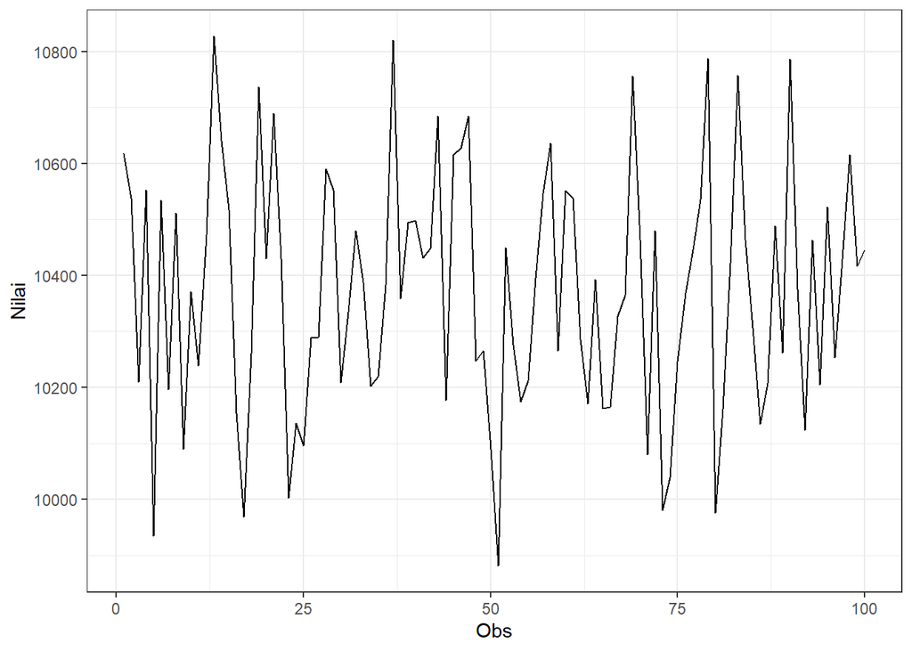

```r
plot_stas <- ts_data |> as_tsibble() |>
  ggplot(aes(x = index, y = value)) + geom_line() + theme_bw() +
  xlab("Obs") + ylab("Nilai")
plot_stas
```

```r
mean(ts_data)
```

```
## [1] 10373.29
```

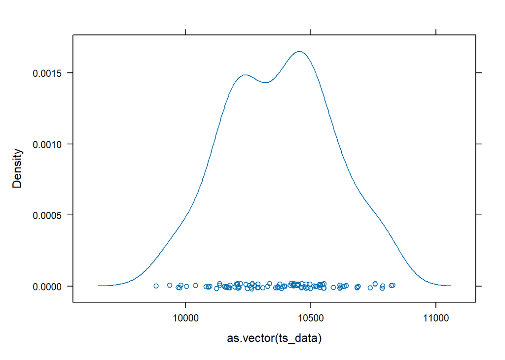

```r
lattice::densityplot(as.vector(ts_data))
```

Plot deret waktu di atas menunjukkan bahwa data stasioner dalam rataan, ditandai dengan data yang menyebar di sekitar nilai tengahnya (10373.29) dan stasioner dalam ragam, ditandai dengan data berfluktuasi pada rentang yang relatif sama sepanjang waktu.

### Plot ACF

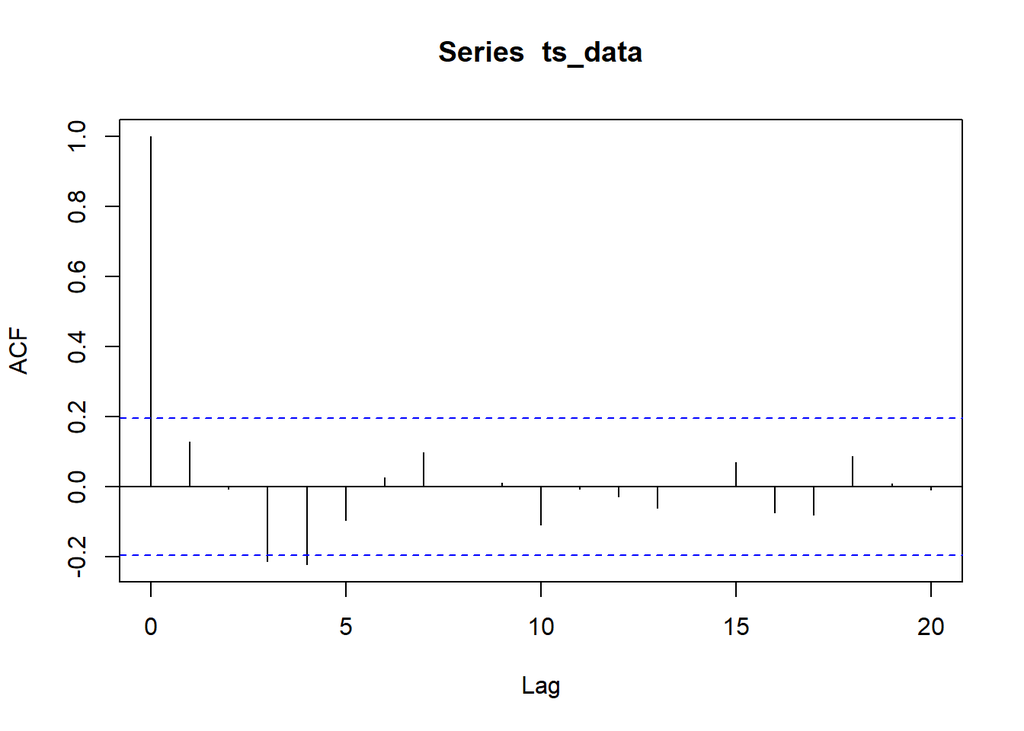

```r
acf(ts_data)
```

Berdasarkan plot ACF, terlihat bahwa plot ACF pada data tersebut cenderung *leg off* setelah lag 1 dan membentuk gelombang sinus.

### Uji ADF

Uji ADF (Augmented Dickey–Fuller) adalah uji statistik yang digunakan untuk memeriksa apakah suatu deret waktu stasioner dalam rataan.

```r
tseries::adf.test(ts_data)
```

```
##
##  Augmented Dickey-Fuller Test
##
## data:  ts_data
## Dickey-Fuller = -5.5967, Lag order = 4, p-value = 0.01
## alternative hypothesis: stationary
```

$H_0$ : Data tidak stasioner dalam rataan

$H_1$ : Data stasioner dalam rataan

Berdasarkan uji ADF tersebut, didapat *p-value* sebesar 0.01 yang lebih kecil dari taraf nyata 5% sehingga tolak $H_0$ dan menandakan bahwa data **stasioner dalam rataan**. Hal ini sesuai dengan hasil eksplorasi menggunakan plot time series dan plot ACF.

### Plot Box-Cox

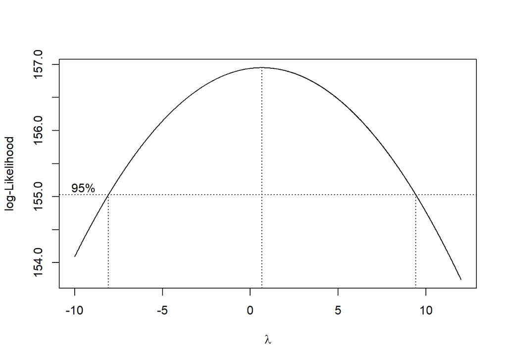

```r
index <- seq(1:100)

# Box-Cox
bc <- boxcox(
  ts_data ~ index,
  lambda = seq(-10, 12, 0.01)
)
```

```r
# Nilai lambda optimum
lambda <- bc$x[which.max(bc$y)]
lambda
```

```
## [1] 0.65
```

```r
# Selang kepercayaan 95% untuk lambda
ci_lambda <- bc$x[bc$y > max(bc$y) - 0.5 * qchisq(0.95, 1)]

# Batas bawah dan batas atas
ci_lower <- min(ci_lambda)
ci_upper <- max(ci_lambda)

c(Batas_Bawah = ci_lower, Batas_Atas = ci_upper)
```

```
## Batas_Bawah  Batas_Atas
##       -8.07        9.42
```

Gambar di atas menunjukkan nilai λ optimum (rounded value) sebesar **0.65** dan selang kepercayaan 95% nilai memiliki batas bawah **-8.07** dan batas atas **9.42**. Selang tersebut memuat nilai satu sehingga dapat dikatakan bahwa data **stasioner dalam ragam**.

### Partisi Data Deret Waktu

membuat data menjadi time series dan membagi menjdai train 80 dan test 20

```r
n <- length(ts_data)
n_train <- floor(0.8 * n)

train_ts <- window(ts_data, end = c(n_train))
test_ts  <- window(ts_data, start = c(n_train + 1))
```

menggunakan data train untuk eksplorasi dan penanganan kestationerannya

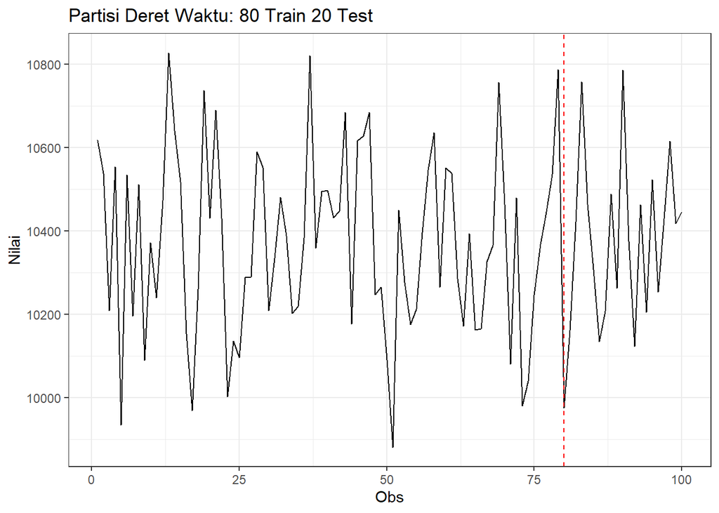

```r
library(ggplot2)
library(tsibble)

plot_stas <- ts_data |>
  as_tsibble() |>
  ggplot(aes(x = index, y = value)) +
  geom_line() +
  theme_bw() +
  xlab("Obs") +
  ylab("Nilai") +

  # Tambahkan garis batas
  geom_vline(xintercept = 80, linetype = "dashed", color = "red") +
  ggtitle("Partisi Deret Waktu: 80 Train 20 Test")

plot_stas
```

### Bagian 1 : train

```r
#rata-rata
mean(train_ts)
```

```
## [1] 10368.62
```

```r
#varians
var(train_ts)
```

```
## [1] 50224.08
```

#### Plot Time Series

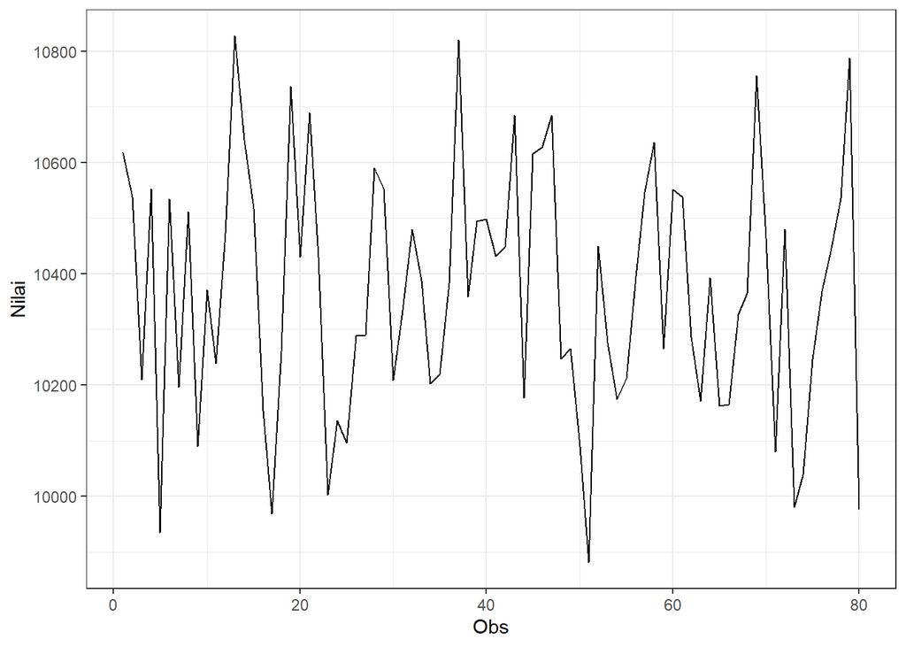

```r
train_ts |> as_tsibble() |>
  ggplot(aes(x = index, y = value)) +
  geom_line() + theme_bw() +
  xlab("Obs") + ylab("Nilai")
```

Plot deret waktu di atas menunjukkan bahwa data stasioner dalam rataan, ditandai dengan data yang menyebar di sekitar nilai tengahnya (10368.62) dan stasioner dalam ragam, ditandai dengan data berfluktuasi pada rentang yang relatif sama sepanjang waktu.

#### Plot ACF

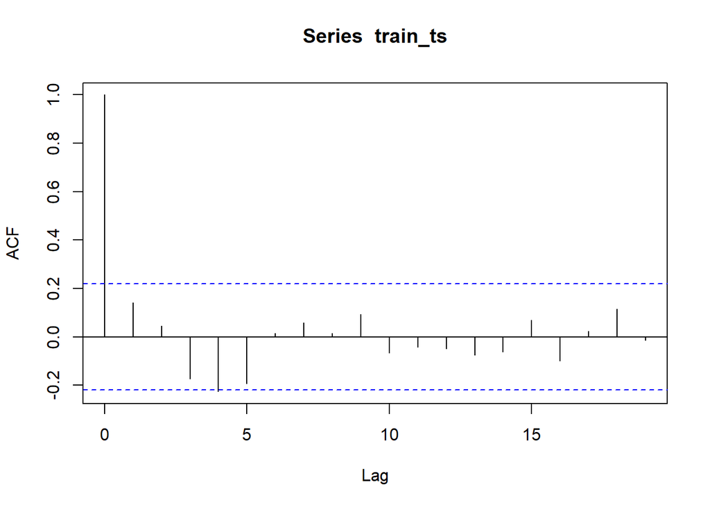

```r
acf(train_ts)
```

Berdasarkan plot ACF, terlihat bahwa plot ACF pada data tersebut cenderung *leg off* setelah lag 1 dan membentuk gelombang sinus.

#### Uji ADF

```r
tseries::adf.test(train_ts)
```

```
##
##  Augmented Dickey-Fuller Test
##
## data:  train_ts
## Dickey-Fuller = -5.3662, Lag order = 4, p-value = 0.01
## alternative hypothesis: stationary
```

$H_0$ : Data tidak stasioner dalam rataan

$H_1$ : Data stasioner dalam rataan

Berdasarkan uji ADF tersebut, didapat *p-value* sebesar 0.01 yang lebih kecil dari taraf nyata 5% sehingga tolak $H_0$ dan menandakan bahwa data **stasioner dalam rataan**. Hal ini sesuai dengan hasil eksplorasi menggunakan plot time series dan plot ACF.

#### Plot Boxcox

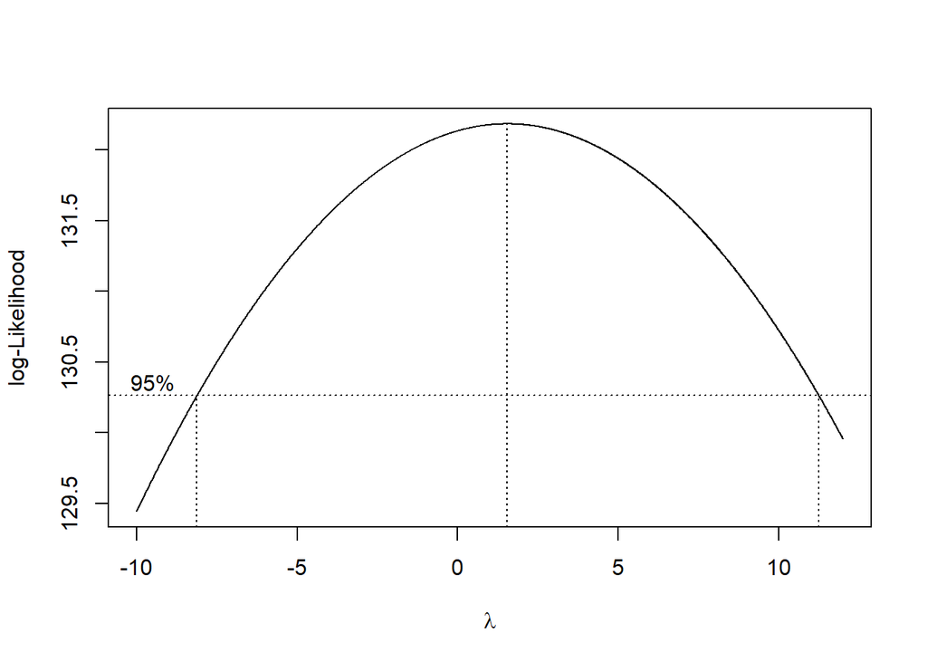

```r
index <- seq(1, 80)

# Box-Cox
bc <- boxcox(
  train_ts ~ index,
  lambda = seq(-10, 12, by = 0.01)
)
```

```r
# Nilai lambda optimum (dibulatkan)
lambda <- bc$x[which.max(bc$y)]
lambda
```

```
## [1] 1.54
```

```r
# Selang kepercayaan 95% untuk lambda
ci_lambda <- bc$x[bc$y > max(bc$y) - 0.5 * qchisq(0.95, 1)]

# Batas bawah dan batas atas
ci_lower <- min(ci_lambda)
ci_upper <- max(ci_lambda)

c(Batas_Bawah = ci_lower, Batas_Atas = ci_upper)
```

```
## Batas_Bawah  Batas_Atas
##       -8.11       11.24
```

Gambar di atas menunjukkan nilai *rounded value* ($\lambda$) optimum sebesar **1.54** dan pada selang kepercayaan 95% nilai memiliki batas bawah **-8.11** dan batas atas **11.24**. Selang tersebut memuat nilai satu sehingga dapat dikatakan bahwa data bangkitan stasioner dalam ragam.

Karena data sudah stationer pada rata-rata dan ragam, maka tidak perlu dilakukan penanganan lebih lanjut.